# Homework: Simple Linear Regression’s Assumptions

Carlos Rodriguez

11/29/2017

1. A description of the data – the variables, the origin of the data and the data set (suchthat I could find it and replicate your work).

The data I will be using is the World Happiness data from the year 2017 from the website, (https://www.kaggle.com/unsdsn/world-happiness/data). The variables I will focus on will be on the Health(life expectancy) and the variable Family, which is social support.

2. An appropriate plot to display the data with respect to your analysis.

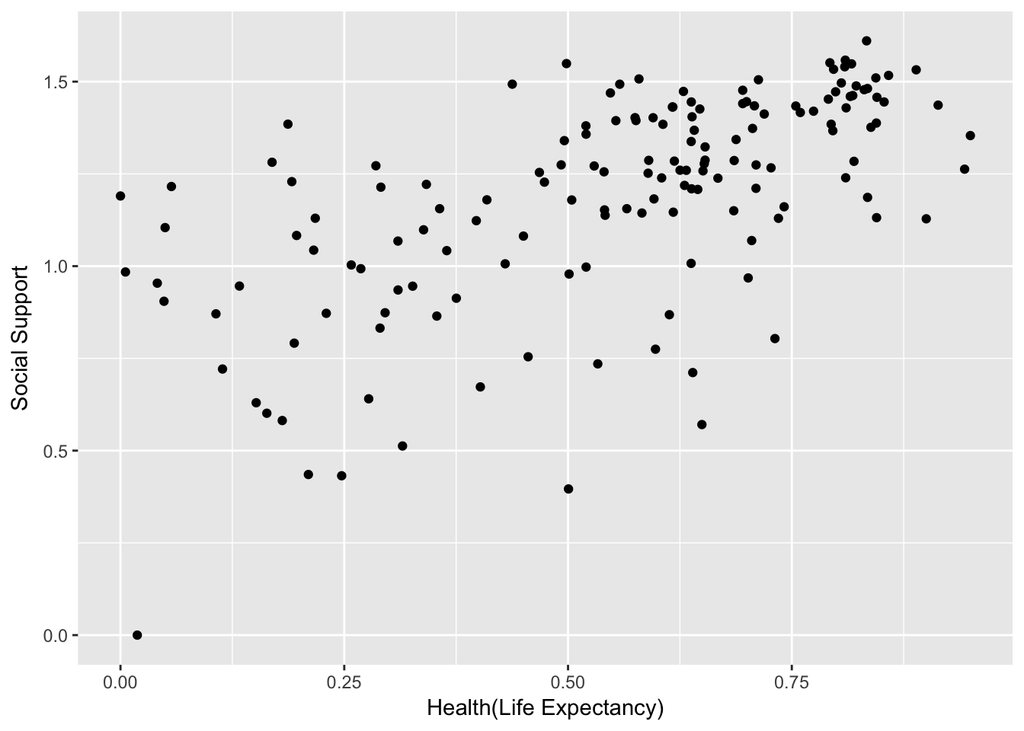

```r
library(ggplot2)
load("Happines2017.RData")
colnames(Happines2017)[8] <- "Health_life_expectancy"
hfplot <- ggplot(data=Happines2017, aes(Health_life_expectancy, Family)) + geom_point() + labs(x="Health(Life Expectancy)", y="Social Support")
hfplot
```

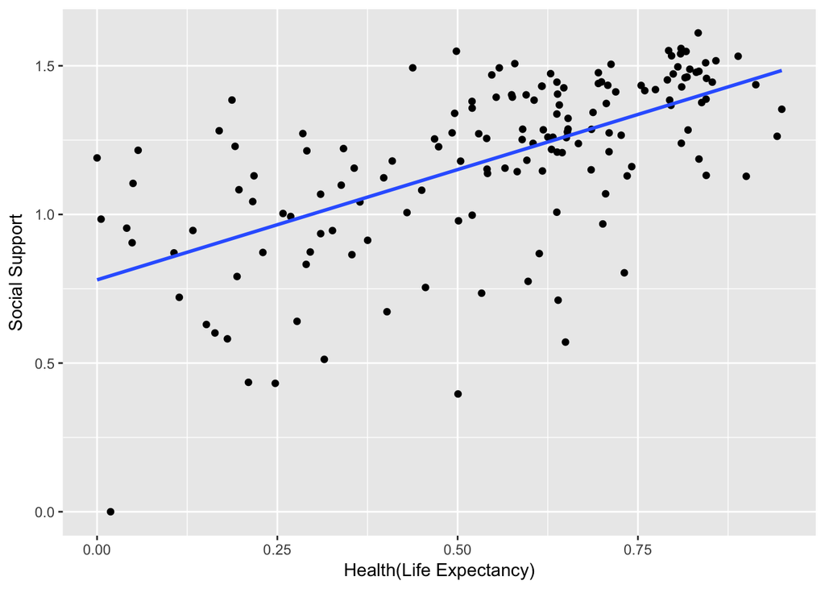

```r
hfplot + stat_smooth(method="lm", se=FALSE)
```

4. As least two plots detailing the assumptions of your model, and multiple sentences describing how well (all) the assumptions of linear regression hold. Even if the assumptions are not met, continue with the rest of the assignment.

```r
library(ggplot2)
hfReg <- lm(Family~Health_life_expectancy, data=Happines2017)
e <- rstandard(hfReg)
yhat_hf <- fitted(hfReg)
summary(hfReg)
```

```
##
## Call:
## lm(formula = Family ~ Health_life_expectancy, data = Happines2017)
##
## Residuals:
##      Min       1Q   Median       3Q      Max
## -0.79391 -0.09410  0.04842  0.14904  0.46605
##
## Coefficients:
##                        Estimate Std. Error t value Pr(>|t|)
## (Intercept)             0.77999    0.04647  16.785   <2e-16 ***
## Health_life_expectancy  0.74166    0.07747   9.574   <2e-16 ***
## ---
## Signif. codes:  0 '***' 0.001 '**' 0.01 '*' 0.05 '.' 0.1 ' ' 1
##
## Residual standard error: 0.2279 on 153 degrees of freedom
## Multiple R-squared:  0.3746, Adjusted R-squared:  0.3706
## F-statistic: 91.66 on 1 and 153 DF,  p-value: < 2.2e-16
```

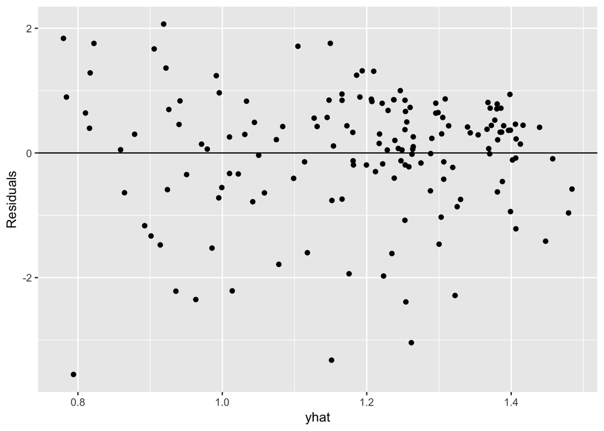

```r
qplot(yhat_hf, e) + geom_hline(aes(yintercept=0)) + xlab("yhat")+ylab("Residuals")
```

The residuals from our model show that there is no clear pattern with dependency to yhat. The width of the residuals are roughly equal width with a little more density after yhat=1.2.

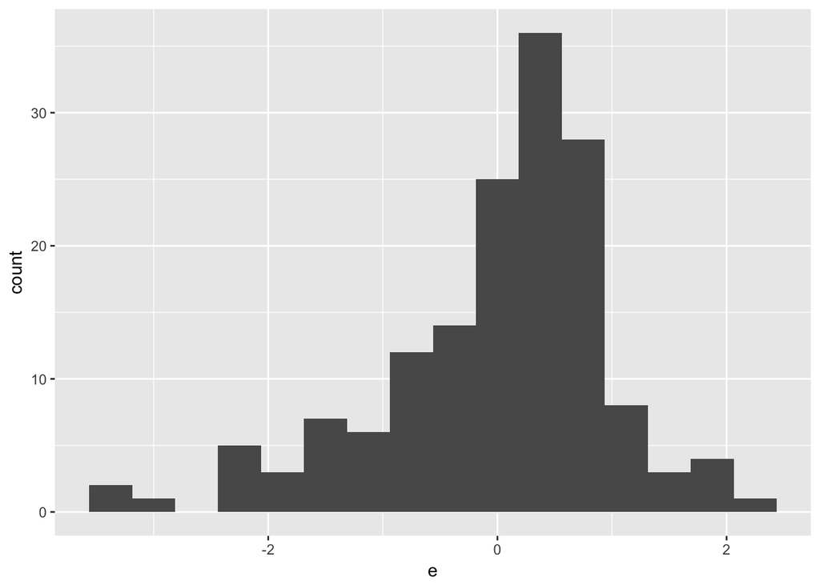

```r
library(ggplot2)
qplot(e, geom="histogram", binwidth=3/8)
```

5. An interpretation in context of both the slope and the intercept.

```r
summary(hfReg)
```

```
##
## Call:
## lm(formula = Family ~ Health_life_expectancy, data = Happines2017)
##
## Residuals:
##      Min       1Q   Median       3Q      Max
## -0.79391 -0.09410  0.04842  0.14904  0.46605
##
## Coefficients:
##                        Estimate Std. Error t value Pr(>|t|)
## (Intercept)             0.77999    0.04647  16.785   <2e-16 ***
## Health_life_expectancy  0.74166    0.07747   9.574   <2e-16 ***
## ---
## Signif. codes:  0 '***' 0.001 '**' 0.01 '*' 0.05 '.' 0.1 ' ' 1
##
## Residual standard error: 0.2279 on 153 degrees of freedom
## Multiple R-squared:  0.3746, Adjusted R-squared:  0.3706
## F-statistic: 91.66 on 1 and 153 DF,  p-value: < 2.2e-16
```

The intercept of the firts regression plot was a round 0.78 with as slope of .74. These numbers are fairly close. In other words, this has a positive slope with more social support there tends to be a higher life expectancy.

6. An interpretation of adjusted R2

The adjusted R^2 value is 0.3706. This means that 37.06% of the variation in Social support is explained by the least squares line on Health(Life expectancy)

7. A formal hypothesis.

8. A formal conclusion in both Statistics and such that my Grandmother could understand.

As we see a higher life expectancy in a country there tends to be more social support in that country.